# Question

Para ambientar musicalmente una reunión, se cuenta con tres CDs, cada uno de ellos tiene canciones de salsa (S) y merengue (M). ¿Cuál de los siguientes diagramas representa la situación de seleccionar al azar una canción del CD1, luego una del CD2 y finalmente una del CD3?

**Opción A:**

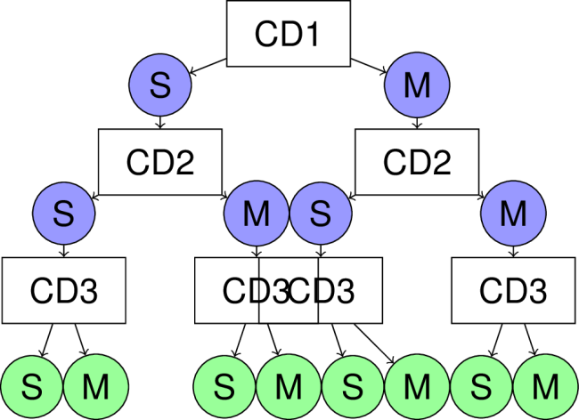

**Opción B:**

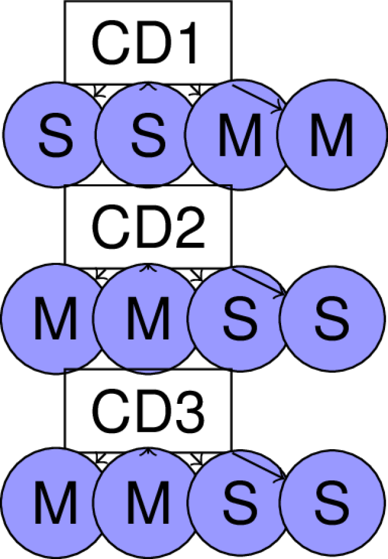

**Opción C:**

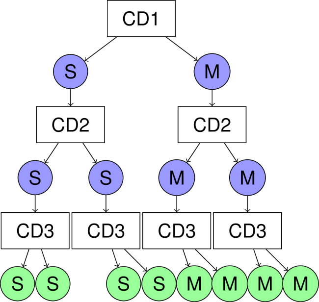

**Opción D:**

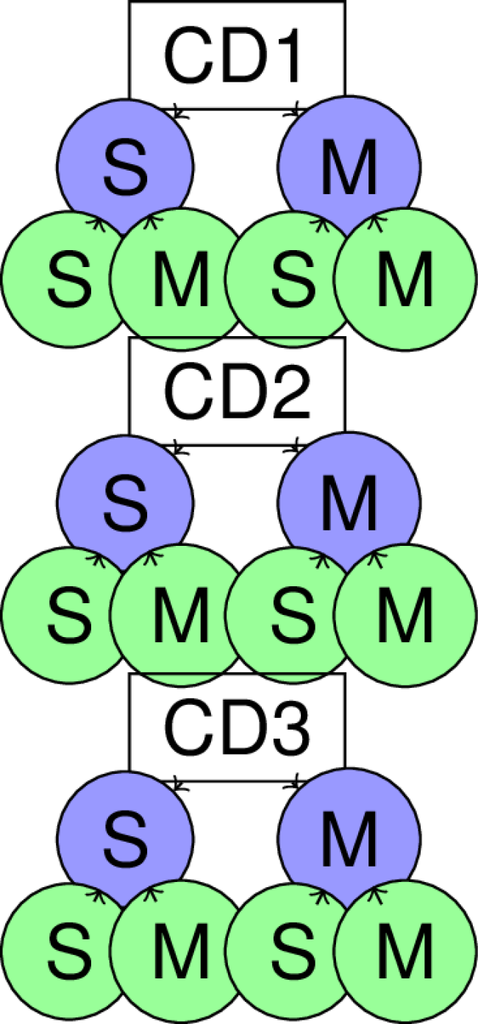

## Answerlist

- Opción A
- Opción B
- Opción C
- Opción D

# Solution

**Diagrama correcto: Opción A**

El diagrama debe representar la **secuencia de decisiones** al seleccionar una canción de cada CD en orden: primero del CD1, luego del CD2, y finalmente del CD3.

**Estructura correcta (Opción A):**

1. **CD1** (inicio): 2 opciones (S o M)
2. **CD2** (segundo nivel): Desde cada opción de CD1, se ramifican 2 nuevas opciones → 4 ramas totales
3. **CD3** (tercer nivel): Desde cada opción de CD2, se ramifican 2 nuevas opciones → 8 resultados finales

**Total de combinaciones:** 2 × 2 × 2 = **8 combinaciones posibles**

**Características del diagrama correcto:**

- Representa un **proceso secuencial** claramente visible
- Los tres niveles (CD1, CD2, CD3) están conectados en una estructura continua
- Cada nivel se desarrolla completamente antes de pasar al siguiente
- Muestra todas las 8 combinaciones posibles: (S-S-S), (S-S-M), (S-M-S), (S-M-M), (M-S-S), (M-S-M), (M-M-S), (M-M-M)

**Análisis de opciones incorrectas:**

Las otras opciones presentan errores conceptuales:

- **Una opción muestra dependencia incorrecta:** Muestra que si se selecciona S del CD1, todas las selecciones posteriores deben ser S. Esto implica una dependencia incorrecta que no existe en el problema (las selecciones son independientes).
- **Una opción muestra diagramas separados:** Muestra tres diagramas **separados** e independientes. No representa una secuencia, sino tres procesos independientes. No muestra cómo la selección del CD2 depende de la selección previa del CD1, ni cómo la selección del CD3 depende de las selecciones previas.
- **Una opción muestra diagramas separados con estructura interna:** Similar al caso anterior, muestra tres diagramas separados, cada uno con su propia estructura de dos niveles. No representa la secuencia CD1 → CD2 → CD3 como un proceso único e interconectado.

**Principio clave:** En un proceso secuencial de selección, cada etapa debe representarse como un nivel en el árbol, y todas las ramas deben desarrollarse completamente antes de pasar al siguiente nivel. El diagrama debe mostrar claramente que el proceso es secuencial y que las selecciones son independientes en cada etapa.

## Answerlist

- Verdadero
- Falso
- Falso
- Falso

# Meta-information

exname: Selección Canciones CD Diagrama Árbol extype: schoice exsolution: 1000 exshuffle: TRUE exsection: Diagramas de Árbol - Probabilidad